# Gentle Introduction to Machine Learning

Module 5: Supervised Learning

Karl Ho

8/9/2020

[Class link](https://datageneration.org/gentlemachinelearning/)

[Class GitHub](https://github.com/datageneration/gentlemachinelearning)

# 1 Supervised Learning

Supervised learning involves prediction on a specified output with algorithms employing input predictor variables. Supervised learning can be classified into:

1. Regression
2. Classication
3. Tree-based models

## 1.1 Regression

Regression methods predict a continuous output variable with predictor data given to the algorithm. Traditional training on regression models focuses on statistical significance but generally misses aspects important for prediction. In particular, when the number of predictor variables increases, prediction will be subject to errors attributed to reducible errors, model biases and irreducible errors.

## 1.2 Classification

Classification methods involve qualitative output variables. These methods include logistic regression, linear discriminant analysis and quadratic discriminant analysis.

## 1.3 Tree-based models

Tree-based methods for regression and classification involve stratifying or segmenting the predictor space into a number of simple regions. The set of splitting rules used to segment the predictor space can be summarized in a tree known as decision-tree.

- Tree-based methods are simple and useful for interpretation.
- However they typically are not competitive with the best supervised learning approaches in terms of prediction accuracy.
- Methods such as bagging, random forests, and boosting grow multiple trees which are then combined to yield a single consensus prediction.
- Combining a large number of trees can improve prediction accuracy but at the expense of interpretation.

### 1.3.1 Decision Tree

- One way to make predictions in a regression problem is to divide the predictor space (i.e. all the possible values for for $X_1,X_2,…,X_p)$ into distinct regions, say $R_1, R_2,…,R_k$
- Then for every $X$ that falls in a particular region (say $R_j$) we make the same prediction.

#### 1.3.1.1 Tree building process

- Predictor space: set of possible values of $X_1, X_2,...,X_i$
- Divide feature space into $J$ distinct and non-overlapping regions, $R_1, R_2,..., R_J$
- Predict by mean of observations in every region $R_j$

### 1.3.3 Random Forest

- Build a number of decision trees on bootstrapped training sample
- When building the trees, each time a split in a tree is considered
- A random sample of $m$ predictors is chosen as split candidates from the full set of $p$ predictors (Usually $m\approx\sqrt{p}$ )
- Why a random sample of $m$ predictors instead of all $p$ predictors for splitting?
- Suppose that we have a very strong predictor in the data set along with a number of other moderately strong predictor, then in the collection of bagged trees, most or all of them will use the very strong predictor for the first split!
- All bagged trees will look similar. Hence all the predictions from the bagged trees will be highly correlated
- Averaging many highly correlated quantities does not lead to a large variance reduction
- Random forests “de-correlates” the bagged trees leading to more reduction in variance

# 2 Hands-on workshop: Regression and Tree-based models

**Regression**

```r
## Gentle Machine Learning
## Linear regression
## Adapted from examples in James, G., Witten, D., Hastie, T., and Tibshirani, R. 2013.
## An Introduction to Statistical Learning with applications in R, New York: Springer

# Boston dataset:
# crim: per capita crime rate by town.
# zn: proportion of residential land zoned for lots over 25,000 sq.ft.
# indus: proportion of non-retail business acres per town.
# chas: Charles River dummy variable (= 1 if tract bounds river; 0 otherwise).
# nox: nitrogen oxides concentration (parts per 10 million).
# rm: average number of rooms per dwelling.
# age: proportion of owner-occupied units built prior to 1940.
# dis: weighted mean of distances to five Boston employment centres.
# rad: index of accessibility to radial highways.
# tax: full-value property-tax rate per \$10,000.
# ptratio: pupil-teacher ratio by town.
# black: 1000(Bk - 0.63)^2 where Bk is the proportion of blacks by town.
# lstat: lower status of the population (percent).
# medv: median value of owner-occupied homes in \$1000s.

library(MASS)
library(ISLR)
library(tidyverse)

# Simple Linear Regression
data(Boston)
names(Boston)
```

```
##  [1] "crim"    "zn"      "indus"   "chas"    "nox"     "rm"      "age"
##  [8] "dis"     "rad"     "tax"     "ptratio" "black"   "lstat"   "medv"
```

```r
lm.fit=lm(medv~lstat,data=Boston)
attach(Boston)
lm.fit=lm(medv~lstat)
lm.fit
```

```
##
## Call:
## lm(formula = medv ~ lstat)
##
## Coefficients:
## (Intercept)        lstat
##       34.55        -0.95
```

```r
summary(lm.fit)
```

```
##
## Call:
## lm(formula = medv ~ lstat)
##
## Residuals:
##     Min      1Q  Median      3Q     Max
## -15.168  -3.990  -1.318   2.034  24.500
##
## Coefficients:
##             Estimate Std. Error t value Pr(>|t|)
## (Intercept) 34.55384    0.56263   61.41   <2e-16 ***
## lstat       -0.95005    0.03873  -24.53   <2e-16 ***
## ---
## Signif. codes:  0 '***' 0.001 '**' 0.01 '*' 0.05 '.' 0.1 ' ' 1
##
## Residual standard error: 6.216 on 504 degrees of freedom
## Multiple R-squared:  0.5441, Adjusted R-squared:  0.5432
## F-statistic: 601.6 on 1 and 504 DF,  p-value: < 2.2e-16
```

```r
names(lm.fit)
```

```
##  [1] "coefficients"  "residuals"     "effects"       "rank"
##  [5] "fitted.values" "assign"        "qr"            "df.residual"
##  [9] "xlevels"       "call"          "terms"         "model"
```

```r
coef(lm.fit)
```

```
## (Intercept)       lstat
##  34.5538409  -0.9500494
```

```r
confint(lm.fit)
```

```
##                 2.5 %     97.5 %
## (Intercept) 33.448457 35.6592247
## lstat       -1.026148 -0.8739505
```

```r
# Prediction intervals will always be wider than confidence intervals
# because they account for the uncertainty associated with epsilon, the irreducible error.
predict(lm.fit,data.frame(lstat=(c(5,10,15))), interval="confidence")
```

```
##        fit      lwr      upr
## 1 29.80359 29.00741 30.59978
## 2 25.05335 24.47413 25.63256
## 3 20.30310 19.73159 20.87461
```

```r
predict(lm.fit,data.frame(lstat=(c(5,10,15))), interval="prediction")
```

```
##        fit       lwr      upr
## 1 29.80359 17.565675 42.04151
## 2 25.05335 12.827626 37.27907
## 3 20.30310  8.077742 32.52846
```

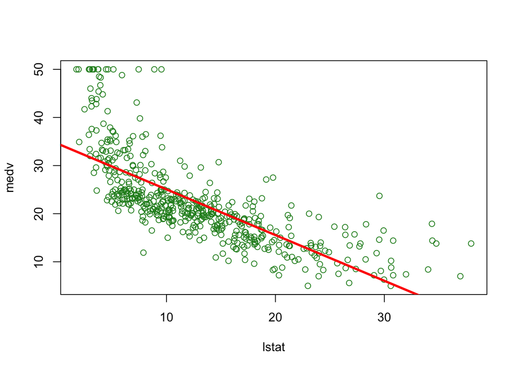

```r
plot(lstat,medv,  col = "forestgreen")
abline(lm.fit,lwd=3,col="red")
```

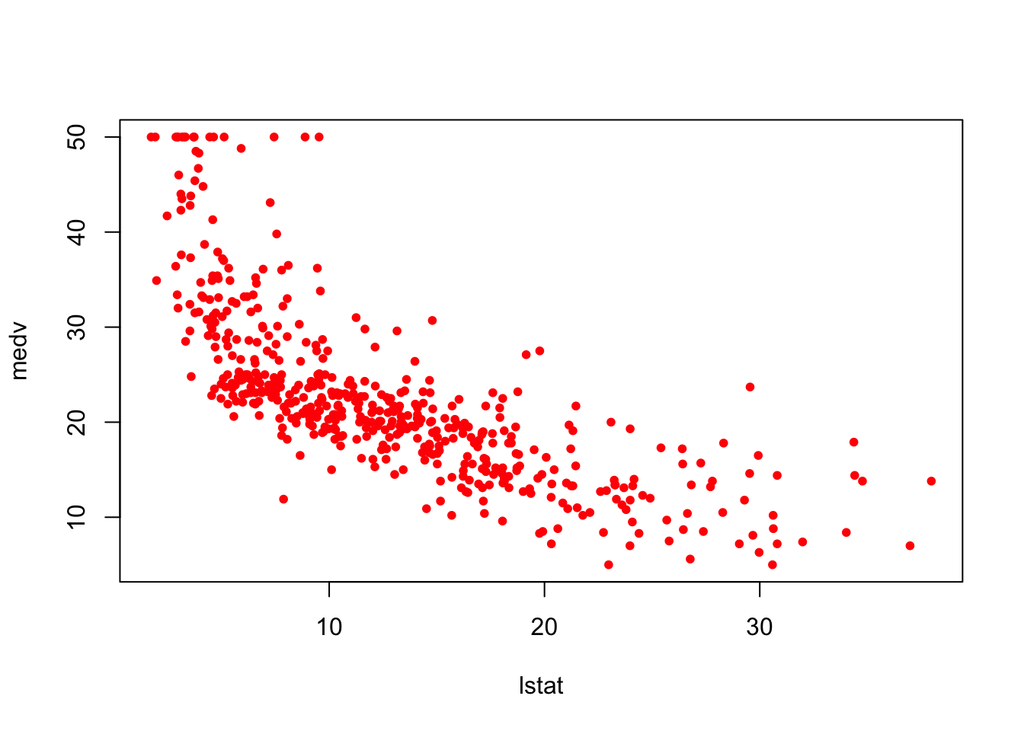

```r
plot(lstat,medv, pch = 20, col="red")
```

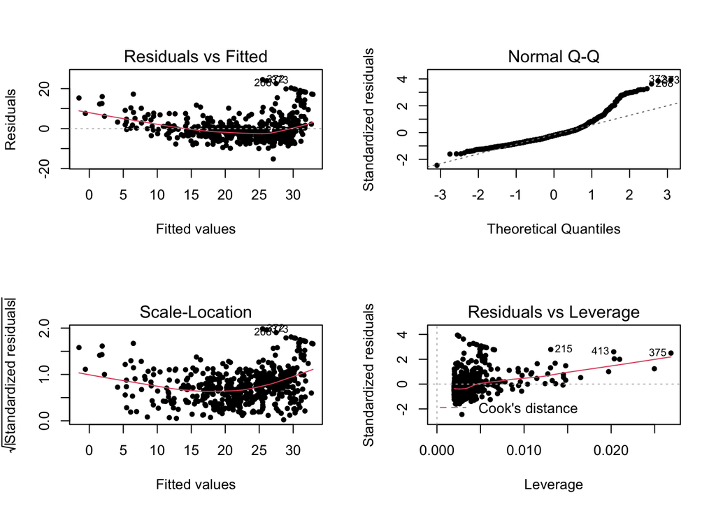

```r
par(mfrow=c(2,2))
plot(lm.fit, pch=20)
```

```r
plot(predict(lm.fit), residuals(lm.fit), pch=20, col = "red")
plot(predict(lm.fit), rstudent(lm.fit), pch=20, col = "forestgreen")
plot(hatvalues(lm.fit), pch=20, col = "darkblue")
which.max(hatvalues(lm.fit))
```

[output not shown]

```
## 375
## 375
```

```r
# Multiple Linear Regression

lm.fit=lm(medv~lstat+age,data=Boston)
summary(lm.fit)
```

```
##
## Call:
## lm(formula = medv ~ lstat + age, data = Boston)
##
## Residuals:
##     Min      1Q  Median      3Q     Max
## -15.981  -3.978  -1.283   1.968  23.158
##
## Coefficients:
##             Estimate Std. Error t value Pr(>|t|)
## (Intercept) 33.22276    0.73085  45.458  < 2e-16 ***
## lstat       -1.03207    0.04819 -21.416  < 2e-16 ***
## age          0.03454    0.01223   2.826  0.00491 **
## ---
## Signif. codes:  0 '***' 0.001 '**' 0.01 '*' 0.05 '.' 0.1 ' ' 1
##
## Residual standard error: 6.173 on 503 degrees of freedom
## Multiple R-squared:  0.5513, Adjusted R-squared:  0.5495
## F-statistic:   309 on 2 and 503 DF,  p-value: < 2.2e-16
```

```r
lm.fit=lm(medv~.,data=Boston)
summary(lm.fit)
```

```
##
## Call:
## lm(formula = medv ~ ., data = Boston)
##
## Residuals:
##     Min      1Q  Median      3Q     Max
## -15.595  -2.730  -0.518   1.777  26.199
##
## Coefficients:
##               Estimate Std. Error t value Pr(>|t|)
## (Intercept)  3.646e+01  5.103e+00   7.144 3.28e-12 ***
## crim        -1.080e-01  3.286e-02  -3.287 0.001087 **
## zn           4.642e-02  1.373e-02   3.382 0.000778 ***
## indus        2.056e-02  6.150e-02   0.334 0.738288
## chas         2.687e+00  8.616e-01   3.118 0.001925 **
## nox         -1.777e+01  3.820e+00  -4.651 4.25e-06 ***
## rm           3.810e+00  4.179e-01   9.116  < 2e-16 ***
## age          6.922e-04  1.321e-02   0.052 0.958229
## dis         -1.476e+00  1.995e-01  -7.398 6.01e-13 ***
## rad          3.060e-01  6.635e-02   4.613 5.07e-06 ***
## tax         -1.233e-02  3.760e-03  -3.280 0.001112 **
## ptratio     -9.527e-01  1.308e-01  -7.283 1.31e-12 ***
## black        9.312e-03  2.686e-03   3.467 0.000573 ***
## lstat       -5.248e-01  5.072e-02 -10.347  < 2e-16 ***
## ---
## Signif. codes:  0 '***' 0.001 '**' 0.01 '*' 0.05 '.' 0.1 ' ' 1
##
## Residual standard error: 4.745 on 492 degrees of freedom
## Multiple R-squared:  0.7406, Adjusted R-squared:  0.7338
## F-statistic: 108.1 on 13 and 492 DF,  p-value: < 2.2e-16
```

```r
library(car)
vif(lm.fit)
```

```
##     crim       zn    indus     chas      nox       rm      age      dis
## 1.792192 2.298758 3.991596 1.073995 4.393720 1.933744 3.100826 3.955945
##      rad      tax  ptratio    black    lstat
## 7.484496 9.008554 1.799084 1.348521 2.941491
```

```r
lm.fit1=lm(medv~.-age,data=Boston)
summary(lm.fit1)
```

```
##
## Call:
## lm(formula = medv ~ . - age, data = Boston)
##
## Residuals:
##      Min       1Q   Median       3Q      Max
## -15.6054  -2.7313  -0.5188   1.7601  26.2243
##
## Coefficients:
##               Estimate Std. Error t value Pr(>|t|)
## (Intercept)  36.436927   5.080119   7.172 2.72e-12 ***
## crim         -0.108006   0.032832  -3.290 0.001075 **
## zn            0.046334   0.013613   3.404 0.000719 ***
## indus         0.020562   0.061433   0.335 0.737989
## chas          2.689026   0.859598   3.128 0.001863 **
## nox         -17.713540   3.679308  -4.814 1.97e-06 ***
## rm            3.814394   0.408480   9.338  < 2e-16 ***
## dis          -1.478612   0.190611  -7.757 5.03e-14 ***
## rad           0.305786   0.066089   4.627 4.75e-06 ***
## tax          -0.012329   0.003755  -3.283 0.001099 **
## ptratio      -0.952211   0.130294  -7.308 1.10e-12 ***
## black         0.009321   0.002678   3.481 0.000544 ***
## lstat        -0.523852   0.047625 -10.999  < 2e-16 ***
## ---
## Signif. codes:  0 '***' 0.001 '**' 0.01 '*' 0.05 '.' 0.1 ' ' 1
##
## Residual standard error: 4.74 on 493 degrees of freedom
## Multiple R-squared:  0.7406, Adjusted R-squared:  0.7343
## F-statistic: 117.3 on 12 and 493 DF,  p-value: < 2.2e-16
```

```r
lm.fit1=update(lm.fit, ~.-age)

# Interaction Terms

summary(lm(medv~lstat*age,data=Boston))
```

```
##
## Call:
## lm(formula = medv ~ lstat * age, data = Boston)
##
## Residuals:
##     Min      1Q  Median      3Q     Max
## -15.806  -4.045  -1.333   2.085  27.552
##
## Coefficients:
##               Estimate Std. Error t value Pr(>|t|)
## (Intercept) 36.0885359  1.4698355  24.553  < 2e-16 ***
## lstat       -1.3921168  0.1674555  -8.313 8.78e-16 ***
## age         -0.0007209  0.0198792  -0.036   0.9711
## lstat:age    0.0041560  0.0018518   2.244   0.0252 *
## ---
## Signif. codes:  0 '***' 0.001 '**' 0.01 '*' 0.05 '.' 0.1 ' ' 1
##
## Residual standard error: 6.149 on 502 degrees of freedom
## Multiple R-squared:  0.5557, Adjusted R-squared:  0.5531
## F-statistic: 209.3 on 3 and 502 DF,  p-value: < 2.2e-16
```

```r
# Non-linear Transformations of the Predictors
lm.fit2=lm(medv~lstat+I(lstat^2))
summary(lm.fit2)
```

```
##
## Call:
## lm(formula = medv ~ lstat + I(lstat^2))
##
## Residuals:
##      Min       1Q   Median       3Q      Max
## -15.2834  -3.8313  -0.5295   2.3095  25.4148
##
## Coefficients:
##              Estimate Std. Error t value Pr(>|t|)
## (Intercept) 42.862007   0.872084   49.15   <2e-16 ***
## lstat       -2.332821   0.123803  -18.84   <2e-16 ***
## I(lstat^2)   0.043547   0.003745   11.63   <2e-16 ***
## ---
## Signif. codes:  0 '***' 0.001 '**' 0.01 '*' 0.05 '.' 0.1 ' ' 1
##
## Residual standard error: 5.524 on 503 degrees of freedom
## Multiple R-squared:  0.6407, Adjusted R-squared:  0.6393
## F-statistic: 448.5 on 2 and 503 DF,  p-value: < 2.2e-16
```

```r
lm.fit=lm(medv~lstat)
anova(lm.fit,lm.fit2)
```

```
## Analysis of Variance Table
##
## Model 1: medv ~ lstat
## Model 2: medv ~ lstat + I(lstat^2)
##   Res.Df   RSS Df Sum of Sq     F    Pr(>F)
## 1    504 19472
## 2    503 15347  1    4125.1 135.2 < 2.2e-16 ***
## ---
## Signif. codes:  0 '***' 0.001 '**' 0.01 '*' 0.05 '.' 0.1 ' ' 1
```

[figure not shown]

```r
par(mfrow=c(2,2))
```

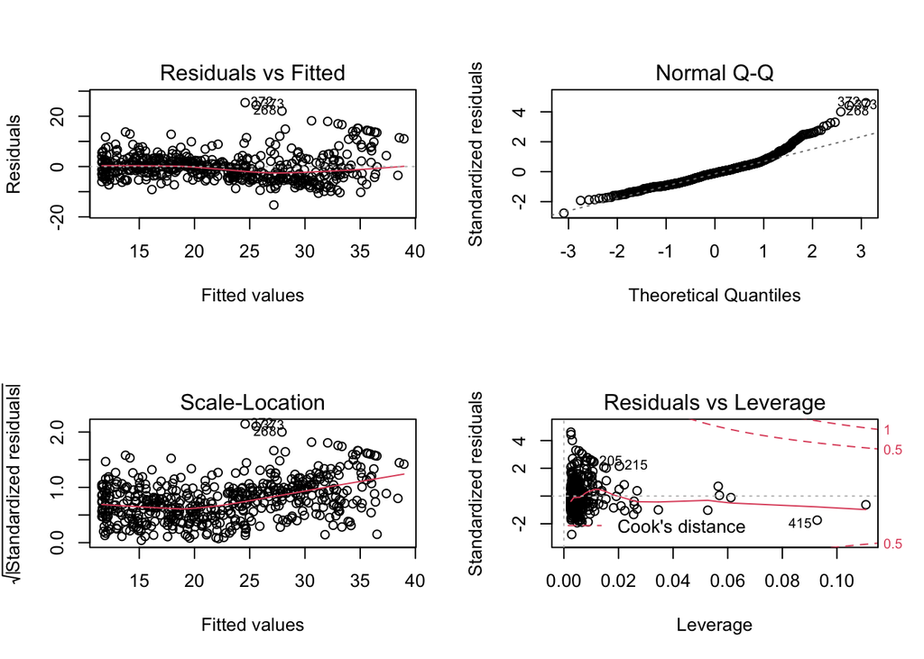

```r
plot(lm.fit2)
```

```r
lm.fit5=lm(medv~poly(lstat,5))
summary(lm.fit5)
```

```
##
## Call:
## lm(formula = medv ~ poly(lstat, 5))
##
## Residuals:
##      Min       1Q   Median       3Q      Max
## -13.5433  -3.1039  -0.7052   2.0844  27.1153
##
## Coefficients:
##                  Estimate Std. Error t value Pr(>|t|)
## (Intercept)       22.5328     0.2318  97.197  < 2e-16 ***
## poly(lstat, 5)1 -152.4595     5.2148 -29.236  < 2e-16 ***
## poly(lstat, 5)2   64.2272     5.2148  12.316  < 2e-16 ***
## poly(lstat, 5)3  -27.0511     5.2148  -5.187 3.10e-07 ***
## poly(lstat, 5)4   25.4517     5.2148   4.881 1.42e-06 ***
## poly(lstat, 5)5  -19.2524     5.2148  -3.692 0.000247 ***
## ---
## Signif. codes:  0 '***' 0.001 '**' 0.01 '*' 0.05 '.' 0.1 ' ' 1
##
## Residual standard error: 5.215 on 500 degrees of freedom
## Multiple R-squared:  0.6817, Adjusted R-squared:  0.6785
## F-statistic: 214.2 on 5 and 500 DF,  p-value: < 2.2e-16
```

```r
summary(lm(medv~log(rm),data=Boston))
```

```
##
## Call:
## lm(formula = medv ~ log(rm), data = Boston)
##
## Residuals:
##     Min      1Q  Median      3Q     Max
## -19.487  -2.875  -0.104   2.837  39.816
##
## Coefficients:
##             Estimate Std. Error t value Pr(>|t|)
## (Intercept)  -76.488      5.028  -15.21   <2e-16 ***
## log(rm)       54.055      2.739   19.73   <2e-16 ***
## ---
## Signif. codes:  0 '***' 0.001 '**' 0.01 '*' 0.05 '.' 0.1 ' ' 1
##
## Residual standard error: 6.915 on 504 degrees of freedom
## Multiple R-squared:  0.4358, Adjusted R-squared:  0.4347
## F-statistic: 389.3 on 1 and 504 DF,  p-value: < 2.2e-16
```

```r
# Advertising example: Model fit
# Advertising dataset: Advertising on TV, Radio and newspaper and sales on a product.
# All units in thousands

advertising=read_csv("https://raw.githubusercontent.com/datageneration/gentlemachinelearning/master/data/Advertising.csv") %>%
  select(c(TV, radio, newspaper,sales))
lm.adv1=lm(sales~.,data=advertising)
lm.adv2=lm(sales~.-newspaper,data=advertising)
summary(lm.adv1)
```

```
##
## Call:
## lm(formula = sales ~ ., data = advertising)
##
## Residuals:
##     Min      1Q  Median      3Q     Max
## -8.8277 -0.8908  0.2418  1.1893  2.8292
##
## Coefficients:
##              Estimate Std. Error t value Pr(>|t|)
## (Intercept)  2.938889   0.311908   9.422   <2e-16 ***
## TV           0.045765   0.001395  32.809   <2e-16 ***
## radio        0.188530   0.008611  21.893   <2e-16 ***
## newspaper   -0.001037   0.005871  -0.177     0.86
## ---
## Signif. codes:  0 '***' 0.001 '**' 0.01 '*' 0.05 '.' 0.1 ' ' 1
##
## Residual standard error: 1.686 on 196 degrees of freedom
## Multiple R-squared:  0.8972, Adjusted R-squared:  0.8956
## F-statistic: 570.3 on 3 and 196 DF,  p-value: < 2.2e-16
```

```r
summary(lm.adv2)
```

```
##
## Call:
## lm(formula = sales ~ . - newspaper, data = advertising)
##
## Residuals:
##     Min      1Q  Median      3Q     Max
## -8.7977 -0.8752  0.2422  1.1708  2.8328
##
## Coefficients:
##             Estimate Std. Error t value Pr(>|t|)
## (Intercept)  2.92110    0.29449   9.919   <2e-16 ***
## TV           0.04575    0.00139  32.909   <2e-16 ***
## radio        0.18799    0.00804  23.382   <2e-16 ***
## ---
## Signif. codes:  0 '***' 0.001 '**' 0.01 '*' 0.05 '.' 0.1 ' ' 1
##
## Residual standard error: 1.681 on 197 degrees of freedom
## Multiple R-squared:  0.8972, Adjusted R-squared:  0.8962
## F-statistic: 859.6 on 2 and 197 DF,  p-value: < 2.2e-16
```

```r
anova(lm.adv1,lm.adv2)
```

```
## Analysis of Variance Table
##
## Model 1: sales ~ TV + radio + newspaper
## Model 2: sales ~ (TV + radio + newspaper) - newspaper
##   Res.Df    RSS Df Sum of Sq      F Pr(>F)
## 1    196 556.83
## 2    197 556.91 -1 -0.088717 0.0312 0.8599
```

```r
# Carseats example: interaction terms
# Carseats datasets: simulated data set containing sales of child car seats at 400 different stores.
# Sales: Unit sales (in thousands) at each location
# CompPrice: Price charged by competitor at each location:
# Income: Community income level (in thousands of dollars)
# Advertising: Local advertising budget for company at each location (in thousands of dollars):
# Population: Population size in region (in thousands)
# Price: Price company charges for car seats at each site:
# ShelveLoc: A factor with levels Bad, Good and Medium indicating the quality of the shelving location for the car seats at each site
# Age: Average age of the local population
# Education: Education level at each location
# Urban: A factor with levels No and Yes to indicate whether the store is in an urban or rural location
# US: A factor with levels No and Yes to indicate whether the store is in the US or not#

names(Carseats)
```

```
##  [1] "Sales"       "CompPrice"   "Income"      "Advertising" "Population"
##  [6] "Price"       "ShelveLoc"   "Age"         "Education"   "Urban"
## [11] "US"
```

```r
# Regression with all variables plus interaction terms
lm.fit=lm(Sales~.+Income:Advertising+Price:Age,data=Carseats)
summary(lm.fit)
```

```
##
## Call:
## lm(formula = Sales ~ . + Income:Advertising + Price:Age, data = Carseats)
##
## Residuals:
##     Min      1Q  Median      3Q     Max
## -2.9208 -0.7503  0.0177  0.6754  3.3413
##
## Coefficients:
##                      Estimate Std. Error t value Pr(>|t|)
## (Intercept)         6.5755654  1.0087470   6.519 2.22e-10 ***
## CompPrice           0.0929371  0.0041183  22.567  < 2e-16 ***
## Income              0.0108940  0.0026044   4.183 3.57e-05 ***
## Advertising         0.0702462  0.0226091   3.107 0.002030 **
## Population          0.0001592  0.0003679   0.433 0.665330
## Price              -0.1008064  0.0074399 -13.549  < 2e-16 ***
## ShelveLocGood       4.8486762  0.1528378  31.724  < 2e-16 ***
## ShelveLocMedium     1.9532620  0.1257682  15.531  < 2e-16 ***
## Age                -0.0579466  0.0159506  -3.633 0.000318 ***
## Education          -0.0208525  0.0196131  -1.063 0.288361
## UrbanYes            0.1401597  0.1124019   1.247 0.213171
## USYes              -0.1575571  0.1489234  -1.058 0.290729
## Income:Advertising  0.0007510  0.0002784   2.698 0.007290 **
## Price:Age           0.0001068  0.0001333   0.801 0.423812
## ---
## Signif. codes:  0 '***' 0.001 '**' 0.01 '*' 0.05 '.' 0.1 ' ' 1
##
## Residual standard error: 1.011 on 386 degrees of freedom
## Multiple R-squared:  0.8761, Adjusted R-squared:  0.8719
## F-statistic:   210 on 13 and 386 DF,  p-value: < 2.2e-16
```

```r
attach(Carseats)
contrasts(ShelveLoc)
```

```
##        Good Medium
## Bad       0      0
## Good      1      0
## Medium    0      1
```

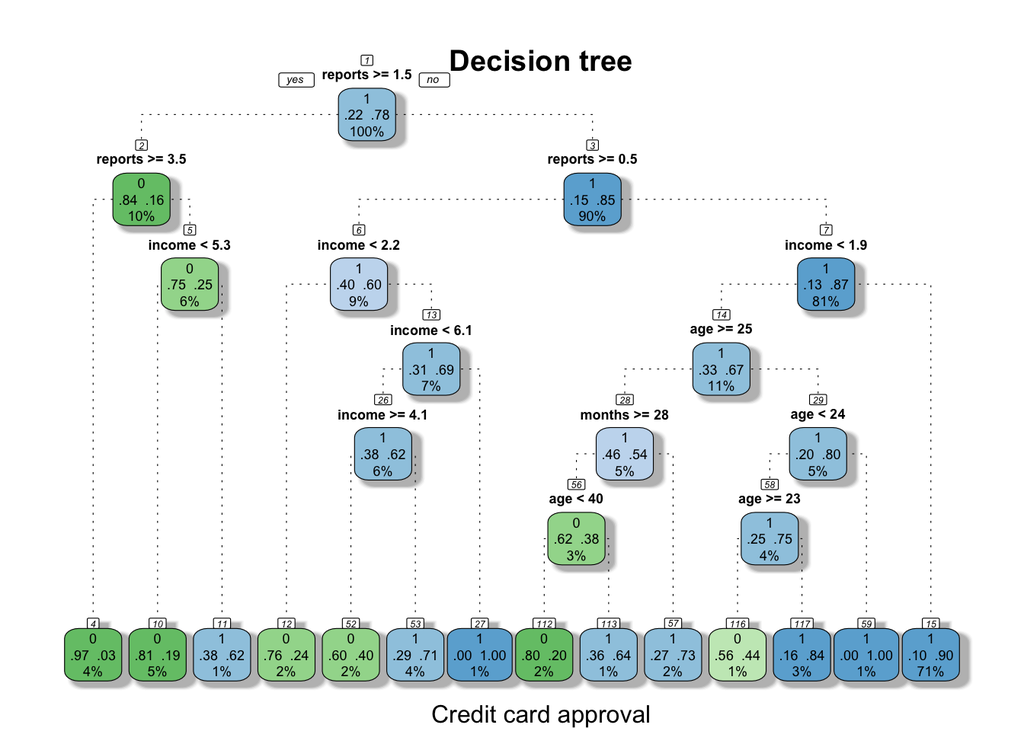

```r
## Supervised Learning (Classification): Tree-based models
## Decision Tree: rpart
## Conditional Inference Tree: party
## Random Forest: randomForest
## Packages used: AER, rpart, rpart.plot, rattle, party, randomForest

#install.packages("rpart")
#install.packages("rpart.plot")
#install.packages("rattle")

library("rpart")
library("rpart.plot")
library("rattle")

# AER Package (AER: Applied Econometrics with R)
# install.packages("AER")
library(AER)

# CreditCard dataset
# card:   "Was the application for a credit card accepted?"
# reports: Number of major derogatory reports.
# age:     Age in years plus twelfths of a year.
# income:  Yearly income (in USD 10,000)
# owner:   Does the individual own their home?
# months:  Months living at current address.
# help("CreditCard") for dataset detail
# Reference: Greene, W.H. (2003). Econometric Analysis, 5th edition.
#            Upper Saddle River, NJ: Prentice Hall.
# Link: http://pages.stern.nyu.edu/~wgreene/Text/tables/tablelist5.htm.

# Load dataset
data(CreditCard)

# Subset data including predictor variables
bankcard <- subset(CreditCard, select = c(card, reports, age, income, owner, months))

# Recode card to 0, 1
bankcard$card <- ifelse(bankcard$card == "yes", 1, 0);

set.seed(1001)
# Order data by row number
newbankcard <- bankcard[sample(nrow(bankcard)),]

# Indexing for training data
t_idx <- sample(seq_len(nrow(bankcard)), size = round(0.70 * nrow(bankcard)))

# Build train and test data
traindata <- newbankcard[t_idx,]
testdata <- newbankcard[ - t_idx,]

# Decision tree model
dtree_creditcard <- rpart::rpart(formula = card ~ ., data = traindata, method = "class", control = rpart.control(cp = 0.001)) # complexity parameter

# Plot Decision tree
rattle::fancyRpartPlot(dtree_creditcard, type = 1, main = "Decision tree", caption = "Credit card approval" )
```

```r
resultdt <- predict(dtree_creditcard, newdata = testdata, type = "class")

# Confusion matrix
cm_creditcarddt <- table(testdata$card, resultdt, dnn = c("Actual", "Predicted"))
cm_creditcarddt
```

```
##       Predicted
## Actual   0   1
##      0  35  57
##      1  18 286
```

```r
# Predicted Approval rate
cm_creditcarddt[4] / sum(cm_creditcarddt[, 2])
```

```
## [1] 0.8338192
```

```r
# Predicted Denial rate
cm_creditcarddt[1] / sum(cm_creditcarddt[, 1])
```

```
## [1] 0.6603774
```

```r
# Accuracy
accuracydt <- sum(diag(cm_creditcarddt)) / sum(cm_creditcarddt)
accuracydt
```

```
## [1] 0.8106061
```

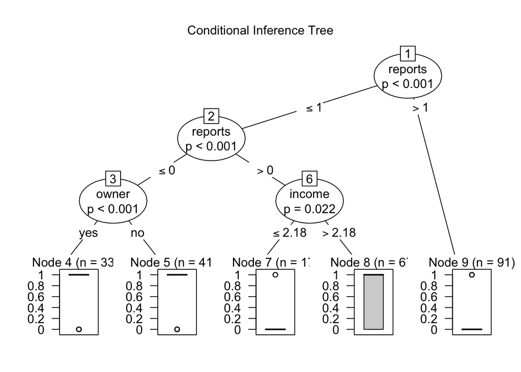

```r
# install.packages("party")
library(party)

# Conditional Inference Tree
cit <- ctree(card ~ ., data = traindata)
plot(cit, main = "Conditional Inference Tree")
```

```r
# Confusion matrix
cm_creditcardcit = table(testdata$card, round(predict(cit, newdata = testdata)), dnn = c("Actual", "Predicted"))

# Predicted Approval rate
cm_creditcardcit[4] / sum(cm_creditcardcit[, 2])
```

```
## [1] 0.8271955
```

```r
# Predicted Denial rate
cm_creditcardcit[1] / sum(cm_creditcardcit[, 1])
```

```
## [1] 0.7209302
```

```r
# Accuracy
accuracycit <- sum(diag(cm_creditcardcit)) / sum(cm_creditcardcit)
accuracycit
```

```
## [1] 0.8156566
```

```r
# Random Forest
# install.packages("randomForest")
library(randomForest)
set.seed(1001)

# randomForest model
rf_creditcard <- randomForest(card ~ ., data = traindata, importance = T, proximity = T, do.trace = 100)
```

```
##      |      Out-of-bag   |
## Tree |      MSE  %Var(y) |
##  100 |   0.1254    72.82 |
##  200 |   0.1247    72.41 |
##  300 |   0.1244    72.25 |
##  400 |   0.1244    72.28 |
##  500 |   0.1239    71.97 |
```

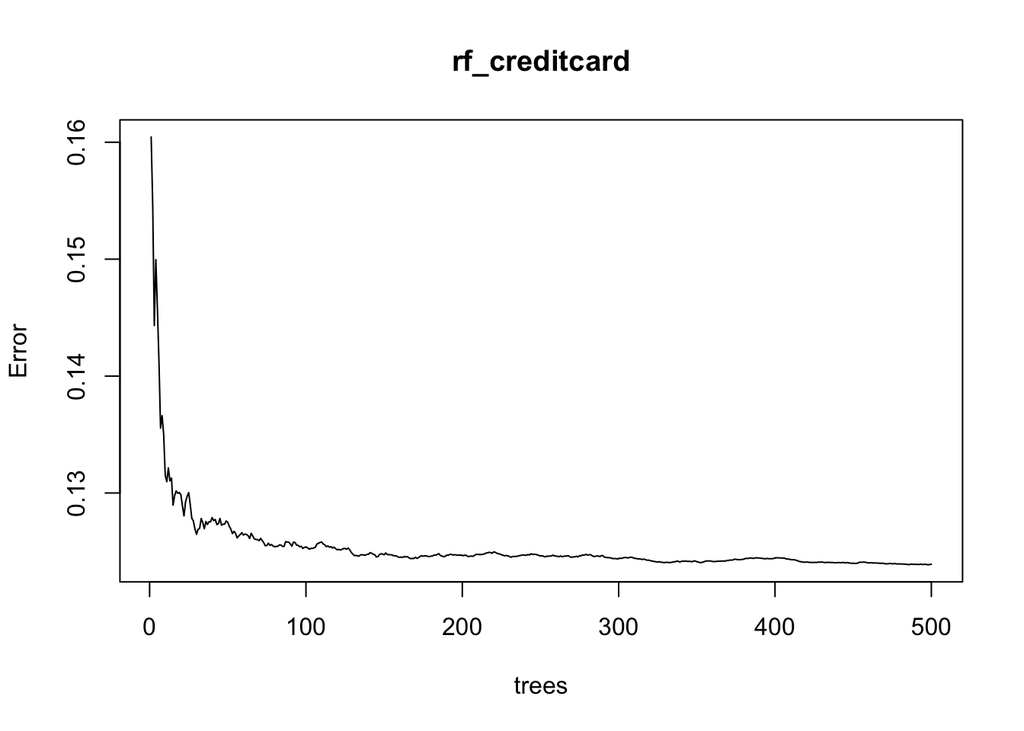

```r
plot(rf_creditcard)
```

```r
round(importance(rf_creditcard), 3) # to three decimal place
```

```
##         %IncMSE IncNodePurity
## reports  45.173        31.136
## age       7.795        10.158
## income   17.449        12.509
## owner    17.838         3.943
## months    7.410        10.297
```

```r
resultrf <- predict(rf_creditcard, newdata = testdata)
resultrf_Approved <- ifelse(resultrf > 0.6, 1, 0)

# Confusion matrix
cm_creditcardrf <- table(testdata$card, resultrf_Approved, dnn = c("Actual", "Predicted"))
cm_creditcardrf
```

```
##       Predicted
## Actual   0   1
##      0  32  60
##      1  12 292
```

```r
# Predicted Approval rate
cm_creditcardrf[4] / sum(cm_creditcardrf[, 2])
```

```
## [1] 0.8295455
```

```r
# Predicted Denial rate
cm_creditcardrf[1] / sum(cm_creditcardrf[, 1])
```

```
## [1] 0.7272727
```

```r
# Accuracy
accuracyrf <- sum(diag(cm_creditcardrf)) / sum(cm_creditcardrf)
accuracyrf
```

```
## [1] 0.8181818
```

## 2.1 References:

Graham Williams 2011. *Data Mining with Rattle and R: The Art of Excavating Data for Knowledge*